# Prediction of Weight Lifting Exercises Quality

S. Yu

May 22, 2015

### I. Introduction

This is a study in machine learning to find a good-fit algorithm which can predict how well people do weight lifting exercises using a dumbbell. The data was obtained from the Human Activity Recognition web site. The output variable we are interested in is the “Classe” which is a categorial variable in 5 possible values (A, B, C, D, E). For more information about the data set, please visit the [HAR web site](http://groupware.les.inf.puc-rio.br/har).

### II. Loading Libaries and Training Data

```r
library(lattice)
library(ggplot2)
library(caret)
data <- read.csv("https://d396qusza40orc.cloudfront.net/predmachlearn/pml-training.csv")

set.seed(2046)
## partition the original training data into a training set (70%) and a validation set (30%)
inTrain <- createDataPartition(y=data$classe, p=0.7, list=FALSE)
training <- data[inTrain,]
validation <- data[-inTrain,]
```

### III. Exploratory Data Analysis

The original training data has 19622 observations and 160 variables. The last variable (or column) is “classe”.

The structure of the training data is printed below:

```r
str(training, list.len=200)
```

```
## 'data.frame':    13737 obs. of  160 variables:
##  $ X                       : int  1 5 6 7 8 9 11 13 14 15 ...
##  $ user_name               : Factor w/ 6 levels "adelmo","carlitos",..: 2 2 2 2 2 2 2 2 2 2 ...
##  $ raw_timestamp_part_1    : int  1323084231 1323084232 1323084232 1323084232 1323084232 1323084232 1323084232 1323084232 1323084232 1323084232 ...
##  $ raw_timestamp_part_2    : int  788290 196328 304277 368296 440390 484323 500302 560359 576390 604281 ...
##  $ cvtd_timestamp          : Factor w/ 20 levels "02/12/2011 13:32",..: 9 9 9 9 9 9 9 9 9 9 ...
##  $ new_window              : Factor w/ 2 levels "no","yes": 1 1 1 1 1 1 1 1 1 1 ...
##  $ num_window              : int  11 12 12 12 12 12 12 12 12 12 ...
##  $ roll_belt               : num  1.41 1.48 1.45 1.42 1.42 1.43 1.45 1.42 1.42 1.45 ...
##  $ pitch_belt              : num  8.07 8.07 8.06 8.09 8.13 8.16 8.18 8.2 8.21 8.2 ...
##  $ yaw_belt                : num  -94.4 -94.4 -94.4 -94.4 -94.4 -94.4 -94.4 -94.4 -94.4 -94.4 ...
##  $ total_accel_belt        : int  3 3 3 3 3 3 3 3 3 3 ...
##  $ kurtosis_roll_belt      : Factor w/ 397 levels "","-0.016850",..: 1 1 1 1 1 1 1 1 1 1 ...
##  $ kurtosis_picth_belt     : Factor w/ 317 levels "","-0.021887",..: 1 1 1 1 1 1 1 1 1 1 ...
##  $ kurtosis_yaw_belt       : Factor w/ 2 levels "","#DIV/0!": 1 1 1 1 1 1 1 1 1 1 ...
```

[output cut: 146 more lines]

To take a quick look at the correlation of the predictor variables with the output variable “classe”, a feature plot of 4 predictors against “Classe” is plotted below:

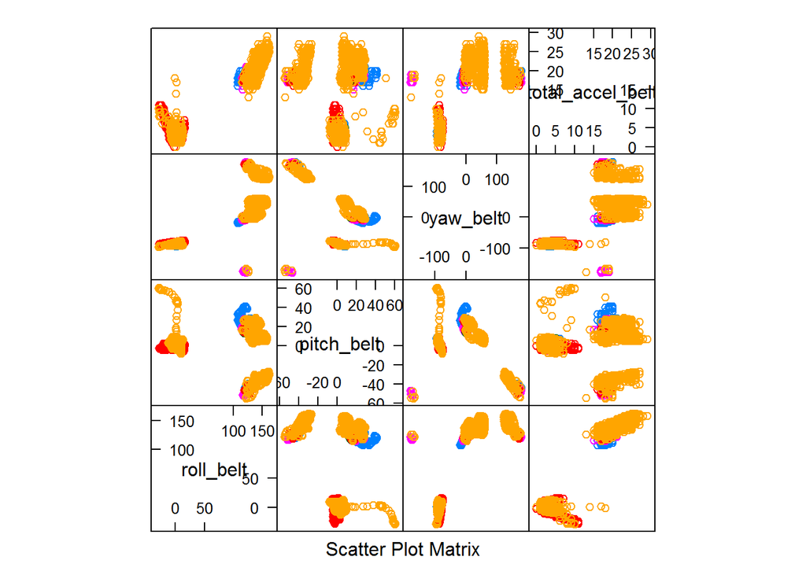

```r
featurePlot(x=training[, c("roll_belt","pitch_belt","yaw_belt","total_accel_belt")], y=training$classe, plot="pairs")
```

### IV. Pre-process Training Data

The first 7 columns in the data set are the general data. They are the row number (variable X), the name of the subject (user_name), timestamp and time-window of each observation. The output variable “Classe” should not depend on the row number and user name. So they are going to be removed before the training. Timestamp and snapshot window are useful for studying how often people do excercise, but they are not quite related to the study of exercise quality. So they are to be removed as well.

Some variables in the original data have many invalid values (> 95%), such as “#DIV/0!” and missing values (NA). When a variable has so many values of these kinds, it would not be a good contributor to the prediction model. In this case, they are removed from the data set.

```r
## Convert invalid value "#DIV/0!" and empty string into NA
training[training == "#DIV/0!" ] = NA
training[training == "" ] = NA

## Convert factor variables into numeric variables
training$kurtosis_roll_belt <- as.numeric(levels(training$kurtosis_roll_belt))[training$kurtosis_roll_belt]
training$kurtosis_picth_belt <- as.numeric(levels(training$kurtosis_picth_belt))[training$kurtosis_picth_belt]
training$kurtosis_yaw_belt <- as.numeric(levels(training$kurtosis_yaw_belt))[training$kurtosis_yaw_belt]
training$skewness_roll_belt <- as.numeric(levels(training$skewness_roll_belt))[training$skewness_roll_belt]
training$skewness_roll_belt.1 <- as.numeric(levels(training$skewness_roll_belt.1))[training$skewness_roll_belt.1]
training$skewness_yaw_belt <- as.numeric(levels(training$skewness_yaw_belt))[training$skewness_yaw_belt]
training$max_yaw_belt <- as.numeric(levels(training$max_yaw_belt))[training$max_yaw_belt]
training$min_yaw_belt <- as.numeric(levels(training$min_yaw_belt))[training$min_yaw_belt]
training$amplitude_yaw_belt <- as.numeric(levels(training$amplitude_yaw_belt))[training$amplitude_yaw_belt]
training$kurtosis_roll_arm <- as.numeric(levels(training$kurtosis_roll_arm))[training$kurtosis_roll_arm]
training$kurtosis_picth_arm <- as.numeric(levels(training$kurtosis_picth_arm))[training$kurtosis_picth_arm]
training$kurtosis_yaw_arm <- as.numeric(levels(training$kurtosis_yaw_arm))[training$kurtosis_yaw_arm]
training$skewness_roll_arm <- as.numeric(levels(training$skewness_roll_arm))[training$skewness_roll_arm]
training$skewness_pitch_arm <- as.numeric(levels(training$skewness_pitch_arm))[training$skewness_pitch_arm]
training$skewness_yaw_arm <- as.numeric(levels(training$skewness_yaw_arm))[training$skewness_yaw_arm]
training$kurtosis_roll_dumbbell <- as.numeric(levels(training$kurtosis_roll_dumbbell))[training$kurtosis_roll_dumbbell]
training$kurtosis_picth_dumbbell <- as.numeric(levels(training$kurtosis_picth_dumbbell))[training$kurtosis_picth_dumbbell]
training$kurtosis_yaw_dumbbell <- as.numeric(levels(training$kurtosis_yaw_dumbbell))[training$kurtosis_yaw_dumbbell]
training$skewness_roll_dumbbell <- as.numeric(levels(training$skewness_roll_dumbbell))[training$skewness_roll_dumbbell]
training$skewness_pitch_dumbbell <- as.numeric(levels(training$skewness_pitch_dumbbell))[training$skewness_pitch_dumbbell]
training$skewness_yaw_dumbbell <- as.numeric(levels(training$skewness_yaw_dumbbell))[training$skewness_yaw_dumbbell]
training$max_yaw_dumbbell <- as.numeric(levels(training$max_yaw_dumbbell))[training$max_yaw_dumbbell]
training$min_yaw_dumbbell <- as.numeric(levels(training$min_yaw_dumbbell))[training$min_yaw_dumbbell]
training$amplitude_yaw_dumbbell <- as.numeric(levels(training$amplitude_yaw_dumbbell))[training$amplitude_yaw_dumbbell]
training$kurtosis_roll_forearm <- as.numeric(levels(training$kurtosis_roll_forearm))[training$kurtosis_roll_forearm]
training$kurtosis_picth_forearm <- as.numeric(levels(training$kurtosis_picth_forearm))[training$kurtosis_picth_forearm]
training$kurtosis_yaw_forearm <- as.numeric(levels(training$kurtosis_yaw_forearm))[training$kurtosis_yaw_forearm]
training$skewness_roll_forearm <- as.numeric(levels(training$skewness_roll_forearm))[training$skewness_roll_forearm]
training$skewness_pitch_forearm <- as.numeric(levels(training$skewness_pitch_forearm))[training$skewness_pitch_forearm]
training$skewness_yaw_forearm <- as.numeric(levels(training$skewness_yaw_forearm))[training$skewness_yaw_forearm]
training$max_yaw_forearm <- as.numeric(levels(training$max_yaw_forearm))[training$max_yaw_forearm]
training$min_yaw_forearm <- as.numeric(levels(training$min_yaw_forearm))[training$min_yaw_forearm]
training$amplitude_yaw_forearm <- as.numeric(levels(training$amplitude_yaw_forearm))[training$amplitude_yaw_forearm]

## remove the columns with more than 95% missing values, i.e. NA
training <- training[,(colSums(is.na(training))/nrow(training)) < 0.95]

## remove the first seven unrelated columns, i.e. row number, user name, timestamp and time windows.
training <- training[, -(1:7)]
```

### V. Cross Validation Setup

```r
## Set up 10-fold cross validation in training
ctrl <- trainControl(method="cv", number = 10)
```

### VI. Machine Learning Algorithm Trainings

We select 4 different algorithms to get trained here to see which one would perform the best.

```r
# Linear Discriminant Analysis (LDA)
modFit_LDA <- train(classe ~ ., data=training, method="lda", trControl=ctrl, verbose=F)

# Bagging
modFit_BAG <- train(classe ~ ., data=training, method="treebag", trControl=ctrl)

# Boosting
modFit_GBM <- train(classe ~ ., data=training, method="gbm", trControl=ctrl, verbose=FALSE)

# Random Forest
modFit_RF <- train(classe ~ ., data=training, method="rf", trControl=ctrl, importance = TRUE)
```

### VII. Model Validation

The validation set which was set aside earlier is used to evaluate the models here.

```r
# LDA
cm_LDA <- confusionMatrix(validation$classe, predict(modFit_LDA, validation)); cm_LDA
```

```
## Confusion Matrix and Statistics
##
##           Reference
## Prediction    A    B    C    D    E
##          A 1351   35  139  143    6
##          B  168  751  124   38   58
##          C   99   96  671  133   27
##          D   57   52  133  688   34
##          E   37  186  102  124  633
##
## Overall Statistics
##
##                Accuracy : 0.6957
##                  95% CI : (0.6837, 0.7074)
##     No Information Rate : 0.2909
##     P-Value [Acc > NIR] : < 2.2e-16
##
##                   Kappa : 0.6151
##  Mcnemar's Test P-Value : < 2.2e-16
##
## Statistics by Class:
##
##                      Class: A Class: B Class: C Class: D Class: E
## Sensitivity            0.7891   0.6705   0.5740   0.6110   0.8351
## Specificity            0.9226   0.9186   0.9247   0.9420   0.9124
## Pos Pred Value         0.8070   0.6594   0.6540   0.7137   0.5850
## Neg Pred Value         0.9143   0.9223   0.8975   0.9110   0.9740
## Prevalence             0.2909   0.1903   0.1986   0.1913   0.1288
## Detection Rate         0.2296   0.1276   0.1140   0.1169   0.1076
## Detection Prevalence   0.2845   0.1935   0.1743   0.1638   0.1839
## Balanced Accuracy      0.8559   0.7946   0.7494   0.7765   0.8738
```

```r
# Bagging
cm_BAG <- confusionMatrix(validation$classe, predict(modFit_BAG, validation)); cm_BAG
```

```
## Confusion Matrix and Statistics
##
##           Reference
## Prediction    A    B    C    D    E
##          A 1670    3    1    0    0
##          B   10 1116   11    1    1
##          C    1   10 1003   12    0
##          D    1    1   19  943    0
##          E    0    2    3    0 1077
##
## Overall Statistics
##
##                Accuracy : 0.9871
##                  95% CI : (0.9839, 0.9898)
##     No Information Rate : 0.2858
##     P-Value [Acc > NIR] : < 2.2e-16
##
##                   Kappa : 0.9837
##  Mcnemar's Test P-Value : NA
##
## Statistics by Class:
##
##                      Class: A Class: B Class: C Class: D Class: E
## Sensitivity            0.9929   0.9859   0.9672   0.9864   0.9991
## Specificity            0.9990   0.9952   0.9953   0.9957   0.9990
## Pos Pred Value         0.9976   0.9798   0.9776   0.9782   0.9954
## Neg Pred Value         0.9972   0.9966   0.9930   0.9974   0.9998
## Prevalence             0.2858   0.1924   0.1762   0.1624   0.1832
## Detection Rate         0.2838   0.1896   0.1704   0.1602   0.1830
## Detection Prevalence   0.2845   0.1935   0.1743   0.1638   0.1839
## Balanced Accuracy      0.9960   0.9905   0.9812   0.9911   0.9990
```

```r
# Boosting
cm_GBM <- confusionMatrix(validation$classe, predict(modFit_GBM, validation)); cm_GBM
```

```
## Confusion Matrix and Statistics
##
##           Reference
## Prediction    A    B    C    D    E
##          A 1655    9    5    4    1
##          B   30 1073   35    0    1
##          C    0   40  970   15    1
##          D    3    3   36  918    4
##          E    1   14   14   19 1034
##
## Overall Statistics
##
##                Accuracy : 0.9601
##                  95% CI : (0.9547, 0.9649)
##     No Information Rate : 0.287
##     P-Value [Acc > NIR] : < 2.2e-16
##
##                   Kappa : 0.9495
##  Mcnemar's Test P-Value : 2.617e-09
##
## Statistics by Class:
##
##                      Class: A Class: B Class: C Class: D Class: E
## Sensitivity            0.9799   0.9421   0.9151   0.9603   0.9933
## Specificity            0.9955   0.9861   0.9884   0.9907   0.9901
## Pos Pred Value         0.9886   0.9421   0.9454   0.9523   0.9556
## Neg Pred Value         0.9919   0.9861   0.9815   0.9923   0.9985
## Prevalence             0.2870   0.1935   0.1801   0.1624   0.1769
## Detection Rate         0.2812   0.1823   0.1648   0.1560   0.1757
## Detection Prevalence   0.2845   0.1935   0.1743   0.1638   0.1839
## Balanced Accuracy      0.9877   0.9641   0.9517   0.9755   0.9917
```

```r
# Random Forest
cm_RF <- confusionMatrix(validation$classe, predict(modFit_RF, validation)); cm_RF
```

```
## Confusion Matrix and Statistics
##
##           Reference
## Prediction    A    B    C    D    E
##          A 1674    0    0    0    0
##          B    4 1132    3    0    0
##          C    0   11 1013    2    0
##          D    0    0   24  940    0
##          E    0    0    2    0 1080
##
## Overall Statistics
##
##                Accuracy : 0.9922
##                  95% CI : (0.9896, 0.9943)
##     No Information Rate : 0.2851
##     P-Value [Acc > NIR] : < 2.2e-16
##
##                   Kappa : 0.9901
##  Mcnemar's Test P-Value : NA
##
## Statistics by Class:
##
##                      Class: A Class: B Class: C Class: D Class: E
## Sensitivity            0.9976   0.9904   0.9722   0.9979   1.0000
## Specificity            1.0000   0.9985   0.9973   0.9951   0.9996
## Pos Pred Value         1.0000   0.9939   0.9873   0.9751   0.9982
## Neg Pred Value         0.9991   0.9977   0.9940   0.9996   1.0000
## Prevalence             0.2851   0.1942   0.1771   0.1601   0.1835
## Detection Rate         0.2845   0.1924   0.1721   0.1597   0.1835
## Detection Prevalence   0.2845   0.1935   0.1743   0.1638   0.1839
## Balanced Accuracy      0.9988   0.9945   0.9847   0.9965   0.9998
```

### VIII. Conclusion

Expected Out of Sample Error rate of the models:

- LDA: **0.3043** (accuracy 0.6957)
- Bagging: **0.0129** (accuracy 0.9871)
- Boosting: **0.0399** (accuracy 0.9601)
- Random Forest: **0.0078** (accuracy 0.9922)

Among these models, **Random Forest** takes a little longer time in training (about 40 minutes), but it has the highest prediction accuracy (**0.9922**) or the lowest error rate (**0.0078**). Based on these results, it is selected as the prediction model.

P.S. The prediction of 20 test cases from a different data set using Random Forest is to be submitted separately.